# Relatorio do Grupo 5

# 3 Análise de Dados

## 3.1 Relatorios de Qualidade das reads

Os relatórios resultantes do fastQC para as bibliotecas inicias, demonstram que estas aparentemente não contêm adaptadores, com todas as reads possuindo entre 62 e 79 pares de bases de comprimento e boa qualidade em todas as métricas. Embora o relatório tenha indicado nos campos “Per base sequence content” e “Sequence Duplication Levels” como tendo possiveis problemas, ao analisar os relatórios estes resultados seriam os esperados em dados de RNA-Seq.

Os relatórios de qualidade após a aplicação do Trimmomatic em algumas bibliotecas apresentam valores de qualidade inferiores aos originais, embora que ainda aceitáveis, de “Per base sequence quality” (exemplo SRR846923_2P e SRR846925_2P).

## 3.2 Carregamento de dados e de um objeto DeSeqDataSet

As contagens foram importadas para R e analisadas utilizando DeSeq2 (versão: 1.22.2). A análise foi feita segundo os seguintes passos:

```r
reads <- read.table("reads_final.tab", h=T, row.names=1, sep = "\t")
```

E em seguida definiram-se as condições de comparação

```r
metadata<-read.table("metadata.txt", sep = ";")
colnames(metadata)<-c("ID","sample","disease")
colnames(reads)=c("csc1_sc2","csc1_dc2","csc1_sc3","csc1_dc3", "csc1-dc","csc1-mc","csc1-sc", "csc2-dc","csc2-mc", "csc2-sc", "csc3-dc","csc3-mc", "csc3-sc", "normal1", "normal2")
```

Antes de correr as funções DeSeq, filtraram-se préviamente os genes com ‘counts’ mais baixos

```r
reads <- reads[ rowSums(reads) > 1, ]
```

## 3.3 Teste de Expressão Diferencial

Em seguida, procedeu-se à execução do teste de expressão diferencial e posterior organização de dados por ordem crescente de valor-p

```r
dds <- DESeqDataSetFromMatrix(countData = reads,colData = metadata, design = ~ disease)
dds <- DESeq(dds)
```

```
## -- replacing outliers and refitting for 34 genes
## -- DESeq argument 'minReplicatesForReplace' = 7
## -- original counts are preserved in counts(dds)
```

```r
# Expressão diferencial de amostras que pertencem a CI vs C2
res <- results(dds)
res
```

```
## log2 fold change (MLE): disease normal vs cancer
## Wald test p-value: disease normal vs cancer
## DataFrame with 2130 rows and 6 columns
##                          baseMean     log2FoldChange             lfcSE
##                         <numeric>          <numeric>         <numeric>
## ENSG00000001617  181.708185547296    2.9554756576702  0.72958023567462
## ENSG00000003756  438.334619768674  0.311062459626725    0.341288278519
## ENSG00000004399  176.012645608335 -0.416935619189362 0.556801931396943
## ENSG00000004534  904.338054111624  0.575516312693059 0.365972921389441
## ENSG00000004838  5.87253887320734   1.86076158027351 0.729500570037265
## ...                           ...                ...               ...
## ENSG00000285969 0.307295362956702   2.26553424449292  3.03121504815687
## ENSG00000286004  8.52462431861836   1.68728115931301 0.774591750961604
## ENSG00000286017  3.40613311126689  -2.57797600306205  1.56112771017181
## ENSG00000286086  13.2939010698339 -0.430685303590031 0.516146752653261
## ENSG00000286168  4.97828521357314  -2.23592751973454  1.54447481608448
##                               stat               pvalue
##                          <numeric>            <numeric>
## ENSG00000001617   4.05092615336183 5.10153072536514e-05
## ENSG00000003756  0.911436106087679     0.36206563670877
## ENSG00000004399 -0.748804189926795    0.453975233989381
## ENSG00000004534   1.57256528845925    0.115819510451414
## ENSG00000004838   2.55073355210464   0.0107496472935874
## ...                            ...                  ...
## ENSG00000285969  0.747401358366336    0.454821325690176
## ENSG00000286004   2.17828444108572   0.0293848667957798
## ENSG00000286017  -1.65135497004171   0.0986661138948933
## ENSG00000286086 -0.834424127200425    0.404042025997941
## ENSG00000286168  -1.44769438546302    0.147702540858745
##                                 padj
##                            <numeric>
## ENSG00000001617 0.000531159375523311
## ENSG00000003756     0.54982894116022
## ENSG00000004399    0.632152576700248
## ENSG00000004534    0.250000650608541
## ENSG00000004838    0.041868430656931
## ...                              ...
## ENSG00000285969                   NA
## ENSG00000286004   0.0900194092416871
## ENSG00000286017    0.222943431822078
## ENSG00000286086    0.593762866618745
## ENSG00000286168    0.294480785466809
```

```r
# Oraganização de tabelas por ordem do menor valor-p
resOrdered <- res[order(res$padj),]
# Sumarização de dados
summary(res)
```

```
##
## out of 2130 with nonzero total read count
## adjusted p-value < 0.1
## LFC > 0 (up)       : 254, 12%
## LFC < 0 (down)     : 290, 14%
## outliers [1]       : 0, 0%
## low counts [2]     : 537, 25%
## (mean count < 1)
## [1] see 'cooksCutoff' argument of ?results
## [2] see 'independentFiltering' argument of ?results
```

```r
# Tem-se muitos valores com p-value inferior a 0.1?
sum(res$padj < 0.1, na.rm=TRUE)
```

```
## [1] 544
```

## 3.4 Exploração e exportação de resultados

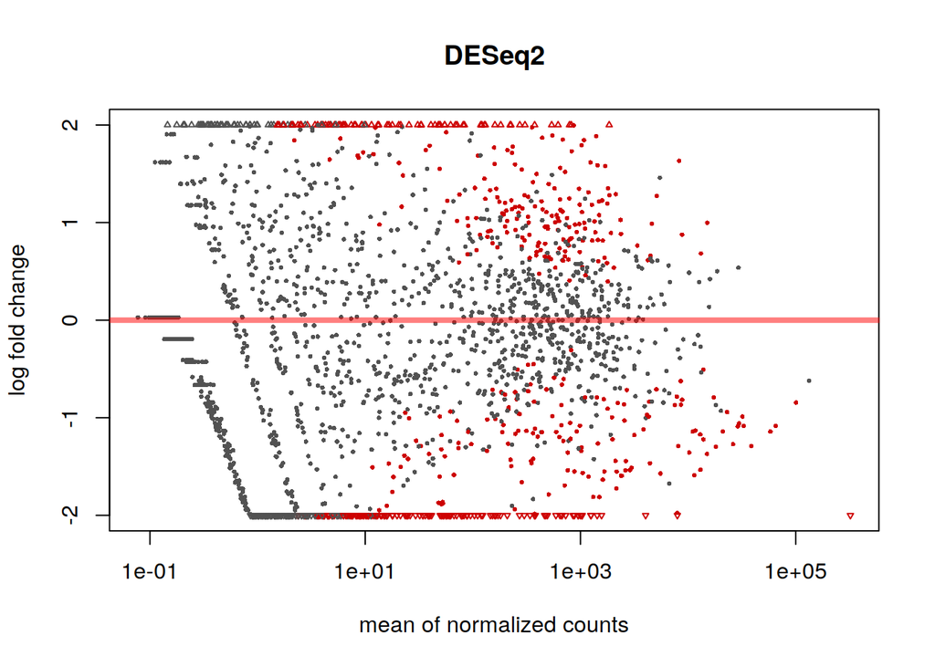

```r
# MA-plot
plotMA(res, main="DESeq2", ylim=c(-2,2))
```

O MA plot) pode representar uma visão geral das diferenças entre as amostras em termos de read counts). Neste gráfico, pode-se verificar que existem vários genes sub e sobre expressos. Se os pontos estivessem distribuídos na zona de y = 0, as amostras seriam bastante similares em termos de expressão génica.

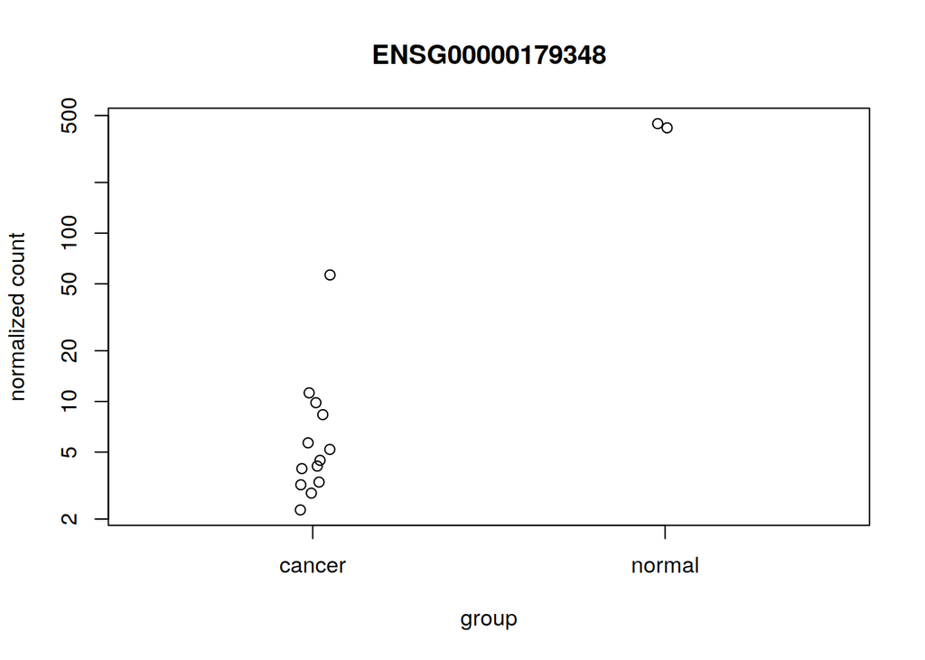

```r
# representar graficamente os read-counts para o gene mais sigfnificante
plotCounts(dds, gene=which.min(res$padj), intgroup="disease")
```

```r
# Exportaçao para um .CSV
write.csv(as.data.frame(resOrdered),file="disease_treated_results.csv")
```

## 3.5 Transofrmação de dados e visualização

Transformação das contagens: Para testar expressão diferencial, operou-se sobre ‘raw counts’ e usaram-se distribuições discretas. Para visualização ou clustering, talvez será melhor trabalhar sobre dados transformados.

```r
# VST: varianceStabilizingTransformation
vsd <- varianceStabilizingTransformation(dds, blind=FALSE)
head(assay(vsd), 20)
```

```
##                  csc1_sc2  csc1_dc2  csc1_sc3  csc1_dc3   csc1-dc
## ENSG00000001617  5.089414  6.418309  6.010239  7.548305  6.124703
## ENSG00000003756  9.074094  8.641985  9.316561  8.283581  8.276009
## ENSG00000004399  6.519280  6.448674  7.153594  7.770129  6.876571
## ENSG00000004534  9.123621  9.179776  9.260982  9.161952  9.645310
## ENSG00000004838  3.528909  4.033408  2.843311  3.130937  2.267487
## ENSG00000007402  4.397699  5.022019  4.207863  4.452644  4.191884
## ENSG00000008226  5.773327  5.769322  5.992636  6.880391  5.802560
## ENSG00000008300  8.607148  8.820437  7.968605  7.342423  8.219529
## ENSG00000008324  8.319001  8.699766  8.211218  8.241842  7.546754
## ENSG00000008952  9.979534 10.233408 10.165287 10.199746 10.273868
## ENSG00000010256 10.856633 10.989122 10.588761 10.701027 11.709065
## ENSG00000010282  2.845873  2.888758  3.076595  2.882524  2.267487
## ENSG00000010318  5.665056  5.474836  5.045394  5.226462  6.039841
## ENSG00000010319  4.557449  3.327864  5.462075  4.678272  4.490518
## ENSG00000010322  9.391320  9.594507  9.197458  9.450947  9.149228
## ENSG00000010327  4.606676  5.140313  4.331808  4.323425  4.349831
## ENSG00000011198  7.655822  7.454801  8.088842  7.799205  7.287447
## ENSG00000011376  8.951454  8.749252  8.936438  8.905499  9.425788
## ENSG00000012171  8.223785 10.085934  7.936911  9.197317  8.707589
## ENSG00000012223  2.267487  2.888758  2.843311  3.317516  2.267487
##                   csc1-mc   csc1-sc   csc2-dc   csc2-mc   csc2-sc
## ENSG00000001617  7.279380  5.148471  5.892116  6.883055  5.052792
## ENSG00000003756  9.309099  8.598165  8.345817  8.938189  8.419886
## ENSG00000004399  6.567041  7.286079  7.083381  8.399809  7.475582
## ENSG00000004534 10.294836  9.275668  9.969253 10.270581  9.340913
## ENSG00000004838  3.913095  3.601060  3.256093  3.932834  3.730610
## ENSG00000007402  4.284043  4.248459  4.278371  5.087873  4.552639
## ENSG00000008226  3.460905  5.611596  5.445441  5.449833  5.508188
## ENSG00000008300  8.470740  7.720163  8.023962  8.454831  7.970413
## ENSG00000008324  6.811054  8.275210  7.676865  7.254436  7.857520
## ENSG00000008952 10.962058 10.524429 10.299450 10.289964 10.274792
## ENSG00000010256 10.689453 11.708567 11.424707 11.485750 11.664369
## ENSG00000010282  2.766221  2.267487  3.079794  3.263363  3.022171
## ENSG00000010318  6.407806  5.874979  6.020302  6.107774  6.128289
## ENSG00000010319  6.387855  5.320393  4.452307  5.527408  4.860440
## ENSG00000010322  9.768244  9.029722  9.077011  9.762979  9.030993
## ENSG00000010327  2.969378  4.564524  4.505480  3.800418  4.367163
## ENSG00000011198  8.823365  7.546939  7.356269  7.243104  7.185905
## ENSG00000011376  8.564536  9.077672  9.401787  9.313188  9.276522
```

[output cut: 8 more lines]

```
## ENSG00000007402  5.681914  5.629966  4.882511  4.149317  4.358836
## ENSG00000008226  6.475762  5.567745  5.356959  4.701058  4.941430
## ENSG00000008300  8.444567  8.951081  8.723306  6.673092  8.234926
## ENSG00000008324  7.438338  7.381878  7.249584  7.295405  7.363135
## ENSG00000008952 10.112816 10.478093 10.861805 10.684585 10.699309
## ENSG00000010256 11.726449 11.241289 10.699433 10.974188 10.946968
## ENSG00000010282  2.267487  2.930480  2.267487  2.267487  2.267487
## ENSG00000010318  5.725506  5.325429  5.178502  6.203500  6.070209
## ENSG00000010319  4.275181  5.207239  5.736561  5.855666  5.972627
## ENSG00000010322  9.541152  9.821382  8.917893 10.079602 10.107591
## ENSG00000010327  5.332086  4.719302  4.439939  2.267487  4.358836
## ENSG00000011198  6.910469  7.635840  7.539151  8.770446  8.934360
## ENSG00000011376  9.258098  9.169062  8.975537 10.135049 10.128864
## ENSG00000012171  9.294428  9.342375  7.828637  8.738975  9.883953
## ENSG00000012223  3.078341  3.197202  2.267487  3.080571  2.267487
```

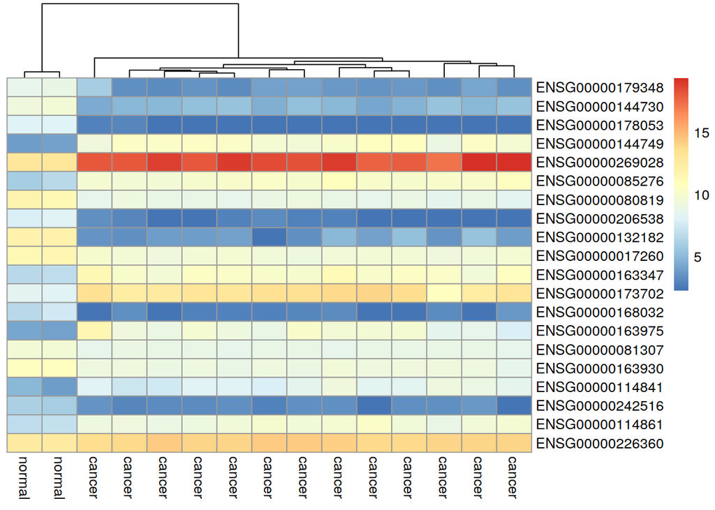

```r
# comparar o comando previo com head(counts(dds), 3)
# Heatmap da matriz dos counts
select <- rownames(head(resOrdered,20))
vsd.counts <- assay(vsd)[select,]
colnames(vsd.counts)<-metadata$disease
df <- as.data.frame(colData(dds)[,c("disease")])
# manter a ordenação das linhas
library(pheatmap)
pheatmap(vsd.counts, cluster_rows=FALSE,show_colnames = T)
```

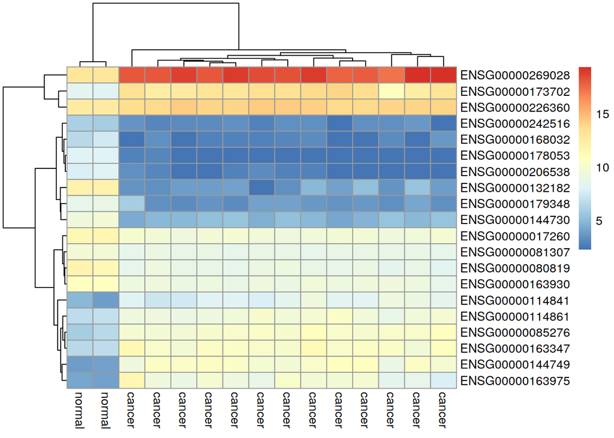

```r
# cluster por linha e coluna
pheatmap(vsd.counts)
```

Os resultados da análise diferencial revelam que o gene com o ENSEMBLE ID ENSG00000269028 foi sobre expresso em células de cancro. O gene é o MTRNR2L12 e a respetiva proteína codificada por ele tem como denominação Humanin-like 12). Esta proteína é codificada por uma pequena open reading frame (ORF) no DNA mitocondrial (mt).[3] A sua função trata-se de suprimir a apoptose [2]. Uma vez que uma disrupção da apoptose está diretamente ligada a cancro [4], este resultado é esperado.

## 3.6 Heatmaps sobre distancia Eucledianas entre amostras

```r
# calcular a distancia entre amostras
sampleDists <- dist(t(assay(vsd)))

# preparar a matriz de distancias
sampleDistMatrix <- as.matrix(sampleDists)
rownames(sampleDistMatrix) <- dds$sample
colnames(sampleDistMatrix) <- NULL
```

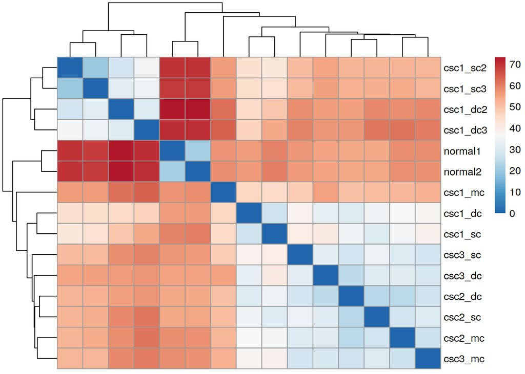

```r
library(RColorBrewer)
colors <- colorRampPalette( rev(brewer.pal(9, "RdBu")) )(255)
pheatmap(sampleDistMatrix, clustering_distance_rows=sampleDists,
         clustering_distance_cols=sampleDists, col=colors)
```

No heatmap acima, é possível verificar que amostras normais tendem a agrupar-se, ao passo que as restantes também agrupam entre si. No entanto, os replicados 2 e 3, recolhidos do primeiro paciente, tendem a agrupar-se ao passo que as restantes (dos pacientes 1, 2 e 3) também formam um cluster diferente.

## 3.7 Analise de componentes principais

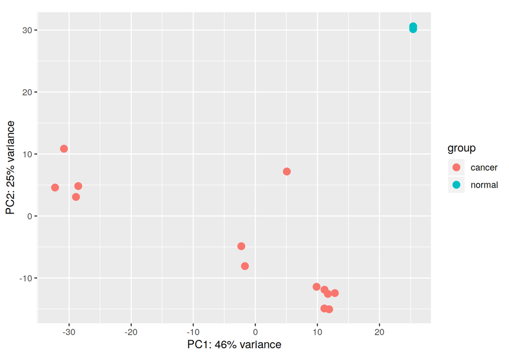

```r
plotPCA(vsd, intgroup=c("disease"))
```

A Principal Component Analysis (PCA) revelou uma separação natural entre pacientes com cancro gástrico e normais.

De modo a encontrar a anotação dos genes, foi utilizado o seguinte comando:

```r
anno <- AnnotationDbi::select(hgu95av2.db,
                              keys=rownames(resOrdered),
                              columns=c("SYMBOL","SYMBOL", "GENENAME"),
                              keytype="ENSEMBL")
```

# 4 Discussão

Os resultados da análise Genómica dos dados de RNA-seq, apesar de terem um comportamento de acordo com o que seria de se esperar, não mostram um panorama geral que possa ser conclusivo. Este fator dever-se-á muito provavelmente ao facto de apenas se estar a avaliar um único cromossoma. Uma posterior genome-wide analysis) trará resultados muito mais conclusivos e poderá ser um dado relevante no entendimento de como mudanças epigenómicas em regiões proximais e distais do genoma humano poderão ter um papel importante no desenvolvimento de cancro gástrico em Humanos.

[1]Baek, S., Kim, M., Bae, D., Kim, J., Kim, H., Han, M., Oh, S., Kim, Y. and Kim, S. (2015). Integrated epigenomic analyses of enhancer as well as promoter regions in gastric cancer. Oncotarget

[2]Guo B, Zhai D, Cabezas E, Welsh K, Nouraini S, Satterthwait AC, Reed JC (May 2003). “Humanin peptide suppresses apoptosis by interfering with Bax activation”. Nature. 423 (6938)

[3]Bodzioch M, Lapicka-Bodzioch K, Zapala B, Kamysz W, Kiec-Wilk B, Dembinska-Kiec A (October 2009). “Evidence for potential functionality of nuclearly-encoded humanin isoforms”. Genomics. 94 (4): 247-56. doi:10.1016/j.ygeno.2009.05.006. PMID 19477263.

[4]Scott W. Lowe, Athena W. Lin, Apoptosis in cancer , Carcinogenesis, Volume 21, Issue 3, March 2000, Pages 485-495